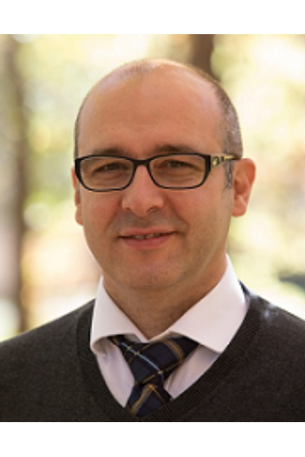

### Carlo Serrangeli

#### Sr. Operation Leadership Manager

###### phone: 513-284-9160

###### e-mail: carlo.serrangeli@gmail.com

###### 10782 Fallsington Ct. - Blue Ash OH 45242 US

## Profile

I'm a digital product development professional with NPI and legacy GE Aviation programs experience, who's passionate about my role and committed to delivering on time and on cost. With over 15 years in software development, my experience spans embedded control software, data science, and analytics software. As a result of this work, I've become well-versed at working with international and cross-functional teams.

## Objective

My goal is to support all phases of a data science project, from understanding the data and making meaningful connections to prototyping and producing a visualization that generates immediate insights and value.

## Education

#### University of Ferrara (Italy) | M.S. Electronic Engineering

Specialization Exams:

Engineering and Technology of Controls Systems

Control Systems Design

Classical/Modern Control System Theory

## Software Proficiency

R/Python

SQL

Javascript/C

Matlab/Simulink

Numerical Propulsion Simulation System (NPSS)

## Experience

#### Sr. Operation Leadership Manager

##### GE Aviation, West Chester (OH)

##### 2018 - Present

**Digital Product: Analytics Core**

Product Owner

Product Owner for GE Aviation Analytic Platform

Define and Execute plan for GE Aviation analytics migration to cloud based platform.

Working with Internal stakeholders to build growth playbook, presenting status and get buy in from senior leadership

Defining system level requirement and driving execution by leading off shore based development team.

#### Sr. Staff Analytics Engineer

##### GE Aviation Digital, Evendale (OH)

##### 2013 - 2018

**Digital Product: Flight Phase Analyzer**

Data Science and Analytics Lead

Design and develop analytics algorithms and visualization insights for GE Aviation customers using QAR data.

Demonstrated ability in synthetizing Continuous Data and set up process to reduce time from data generation to data fruition avoiding ACARS transmission cost.

Provide leadership to the cross-functional team by comprehending customer feedback, creating concepts, and activating them for both the data science and development teams to execute.

**Digital Product: iCDL (Increase Converage and Detection Lead Time) system**

Engineering Product Owner

Execute plan for the migration in iCDL of all legacy analytic modules for the GE Aviation monitored fleet (~30k engines) by managing both a global team of engineers and external contractors.

Lead the design, development, platform integration and testing of NPSS diagnostic algorithms for all GE Aviation engine models.

#### Staff Engineer

##### GE Aviation, Evendale (OH)

##### 2011 - 2013

Lead GEnx-1B and GEnx-2B Engine Monitioring Unit post Entry into Service system level software design and qualification.

#### Lead Engineer

##### GE Oil & Gas, Florence, Italy

##### 2006 - 2011

Lead design and development activities for the standardization of GE Oil & Gas Human Machine Interface products for both Gas and Steam Turbines, Compressors and Generators by coorginating an international team located in Hyderabad, India.

#### Engineer

##### Avio - Turin, Italy

On site Avio GEnx Controls System representative selected for the design, development and testing of both engine control and monitoring system algorithms.

Flight test support engineer and GE on site control system focal point for the first flight test activities of the T700 T6E1 on NH90 helicopter.

## Awards & Recognitions

#### June 2016

#### GE Aviation Systems

#### ERD Presidential Award

Project: ICDL (Increased Coverage and Detection Lead Time)

Reason: Migration of GE Aviation Legacy diagnostic system to Predix based platform.

#### Stay lean to go fast

#### February 24, 2017

Returning value to customers transmitting their Continuous Engine Operational Data is crucial to our success, and the work you've been doing to support Flight Phase Analyzer and Fleet Statics Report are key to demonstrating that value. We appreciate your commitment to evolving our CEOD tools, quickly responding to external and internal customer feedback, and ongoing consultation and guidance on next steps. Our CEOD team values your expertise and we look forward to collaborating with you further this year. Thank you for your enthusiasm and willingness to tackle big challenges.

###### Andrea Poling

#### Empower and inspire each other

#### December 11, 2016

Thank you for a great job planning and putting on the DSS Holiday Party at the zoo. It was a good time and a lot of fun, and no one got eaten by the cheetah! Small token of appreciation for all your hard work and effort! Regards, Justin and Monica.

###### Justin Howe

#### Learn and adapt to win

#### December 8, 2016

This award is in recognition of your significant contribution to Author and release the Trending Methods And Meta-Models Design Practice. Your commitment/focus/dedication to the formal capture of good engineering practices is sincerely appreciated!

###### Curt Bisterfeldt

#### Empower and inspire each other

#### July 18, 2016

Congratulations on winning the Presidential Award. ERD is the highest-level awards that are given in Aviation Digital Solutions organization. It is an honor to receive one of these awards, as there was 1075 nominations submitted this year. Congrats again!

###### Chrissy Buckingham

#### Stay lean to go fast

#### May 8, 2016

Carlo thanks for driving and wrangling a half dozen plus of our analytic creation power users and consulting engineers from around the world to slim down the number of parameters we move from EMS into to the Data Lake. Allowing us to stay lean and go fast as we move to support LEAP EIS. This trimmed down list will allow us to have a more stable data lake and be able to move the remaining backlog of flights. Thanks, Bob

###### Robert Kahn

#### Customers determine our success

#### December 5, 2015

Thank you for your tremendous leadership with the ICDL go live. This is a significant milestone for GE Aviation and GE Digital which had many complex pieces, but your leadership helped deliver this program on time and on budget for the business. Senior leadership continues to be very impressed with the cross-functional collaboration and "can do" attitude of this team.

###### Patrick Saad

#### Customers determine our success

#### July 28, 2015

The Predix Insight Explorer tool fills a crucial need in Fleet Support. The tool provides rapid access to all configurations in the Predix ICDL environment, allowing Fleet Support to understand and review the ICDL analytics set-ups in several useful formats. The team created this tool on their own initiative, recognizing the limitations of the current process and anticipating Fleet Support's needs as they constructed this tool over the course of only a few weeks. The Insight Explorer provided an immediate impact to Fleet Support the first day it was released, and it should be used by GE Software Center's Predix team as a model for future analytics configuration user interfaces.

###### Bob Striebich

#### Customers determine our success

#### May 28, 2015

Carlo - I really cannot state how thankful we are to having you as part of the ICDL program. As you know the ICDL GE90/ GEnx/ CFM56-7 Production release was essentially the most significant accomplishment we've had for this program so far...your validation efforts were a CRITICAL component. Considering the show stopper issues we had pre-release, our customer's fear to continue was something I constantly worried about. Your dedication, expertise, and rigor around validation helped us bring focus back to the data - and enabled objective decisions in the face of adversity. Without the efforts of you and your team, we would not be successful. Thank you!

###### Emile Blache

#### Empower and inspire each other

#### March 27, 2015

Thank you for your efforts in an outstanding day with Aiken students at our 2nd annual Job Shadow Day with Junior Achievement! Your time and energy to create a day of learning (and practicing!) future career options was invaluable and made a major impact on 8th graders as they prepare for high school next year! Thanks again!

###### Emily Thobe

#### Expertise

#### December 18, 2014

Thank you for your leadership and contributions to the Analytics Quality Assurance program in 2014! Your effort and support built a strong foundation of development and testing processes that ensure the quality delivery of analytics in ICDL, enabling the early adoption of GE90 and GENX.

###### Kristen Machen

#### Expertise

#### December 30, 2013

CAAP Pilot Phase 1 Team, Congratulations on a successful first phase implementation of CAAP, the next generation of engine monitoring for GE Aviation. Through your efforts, we have now enabled GE90 in the Predix and NGD platforms with many more engine lines to come! Thank you for going above and beyond to make this happen!

###### Michael Groskopf

#### External Focus

#### July 23, 2013

Carlo created much-needed documents to summarize the GEnx-1B and GEnx-2B event and non-event reports. Until the creation of these documents, the end-users of these reports (AOC), as well as those that have to answer customer questions related to there reports (PSE) were unequipped with formal documentation to aid in use of the EMU reports. These reports will set the bar for informing our internal customers of our reports. Thank you, Carlo, for your diligent effort to compile these documents!

###### Nana Noel

#### External Focus

#### January 22, 2013

Jon and Carlo, lead the effort to develop requirements for the On-board trim balance configuration function. The development of requirements for this function took significant effort over several months, requiring a detailed analysis of Aircraft system behavior. This function will result in customer time savings while on the flight line with regards to Engine vibration systems Maintenance.

###### Joseph Shoaf

#### Expertise

#### October 1, 2012

This is a small token of appreciation and well overdue recognition for your leadership and technical excellence in leading the GEnx-1B and 2B EMU software requirements team into EIS on the 787 and 747. The 747-8 Intercontinental and Freighter Aircraft has 29 planes now in service and on the 787-8 where three airlines are now operating. Your dedication and leadership to ensuring the success of the EMU software is appreciated.

###### Rick Knopf

#### External Focus

#### May 31, 2012

This award is for the successful design, development and implementation of the GEnx EMU Engine Trim Balance software. During recent flight testing of a production B787 aircraft ZA233, engine 956-117 had higher than normal vibration levels. The flight line personnel were able to successfully use the Engine Trim Balance software with the EMU's generic coefficients to compute a fan balance weight change that lowered the vibration levels on the next flight... This was the first time the EMU Engine Trim Balance software was used on a production aircraft, and it worked per the EMU ICD requirements which allowed the aircraft to continue production testing.

###### Mark Butz

#### External Focus

#### November 18, 2011

Thank you for stepping in to support and provide leadership to the GEnx IE team while Ahmed was out of the office. You did an excellent job addressing issues, presenting TG3/TG6, supporting meetings and keeping the team on track, all while keeping up with your normally assigned responsibilities.

###### Katherine Henn

Personal contact information